# BUA 455 - Week 6: Reshaping, Cleaning, and Joining Data

Penelope Pooler Eisenbies

2024-02-20

```r
# this line specifies options for default options for all R Chunks
knitr::opts_chunk$set(echo=T,
                      highlight=T)

# suppress scientific notation
options(scipen=100)

# install helper package (pacman), if needed
if (!require("pacman")) install.packages("pacman", repos = "http://lib.stat.cmu.edu/R/CRAN/")
# install and load required packages
# pacman should be first package in parentheses and then list others
pacman::p_load(pacman, tidyverse, magrittr, lubridate)

# verify packages (comment out in finished documents)
p_loaded()
```

```
##  [1] "magrittr"  "lubridate" "forcats"   "stringr"   "dplyr"     "purrr"
##  [7] "readr"     "tidyr"     "tibble"    "ggplot2"   "tidyverse" "pacman"
```

### Comments About Quiz 1

- Grading is in progress, but can not be discussed until all grades are entered.
- I hope that all quizzes will be graded by this weekend.

### HW 4 is posted and is due next week on Wednesday, 2/28/23.

- We will work through it together on Thursday
- Demo Videos will be posted later this week.

#### R functions:

- Useful for automating repetitive, detailed, data management

Best Practices:

- Plan what you want to do
  - Often useful to write out your planned tasks in english
- Develop and refine the code to complete your tasks
- Subdivide the larger tasks into smaller shorter tasks
- Convert each set of asks into a function
  - When in doubt, make the function more general and less specific so it is more useful

#### Anatomy of a Function (Option 1):

- Commands within function **are not saved** to an object.
- Function results are automatically ‘kicked out’ as output.

```
Function_Name <- function(input_1, input_2, etc){
   command 1 to do "stuff" to inputs |>
   command 2 to do "stuff" to inputs |>
   command 3 to do "stuff" to inputs |> etc. # output is autmatically "kicked out"
}
```

#### Anatomy of a Function (Option 2):

- Commands within function **are saved** to an object.
- Function must end with name of object so that results are ‘kicked out’ as output.

```
Function_Name <- function(input_1, input_2, etc){
   output <- command 1 to do "stuff" to inputs |>
             command 2 to do "stuff" to inputs |>
             command 3 to do "stuff" to inputs |> etc.
   output  # end with name of output so that it is "kicked out" of function
}
```

### Steps for Cleaning Box Office Management Data:

**`1.`** Import raw .csv file and skip header rows above variable names - Examine .csv file to determine number of rows to skip

**`2.`** Select useful columns (Columns 1, 4, 7, and 9):

- 1: `Date`
- 4: `Top 10 Gross` is a character variable with nuisance characters to be removed (`$` and `,`)
- 7: `Releases`
- 9: `Gross` is a character variable with nuisance characters to be removed (`$` and `,`)

**`3.`** Rename these four variables to easier names to work with in R

**`4.`** Remove non-data rows (Holidays and Covid Restriction Days)

**`5.`** Use `mutate` to convert variables to useable formats:

- Use `paste` to add year text to `date` character variable and convert to a date variable.
- Use `gsub` and `as.numeric` to convert each gross variable to numeric:
  - `gsub` is used to remove `$` and `,`
  - `as.numeric` is used to convert character to numeric decimal value (`<dbl>`).

### Cleaning One Data Set:

```r
bom2021 <- read_csv("box_office_mojo_2021.csv", skip=10) |>
  select(1,4,7,9) |>
  rename("date" = "Date",
         "top10gross" = "Top 10 Gross",
         "num_releases" = "Releases",
         "num1gross" = "Gross") |>
  filter(!is.na(top10gross)) |>
  mutate(date = dmy(paste(date,2021)),
         top10gross = gsub(pattern="$", replacement="", x=top10gross, fixed=T),
         top10gross = gsub(pattern=",", replacement="", x=top10gross, fixed=T) |>
           as.numeric(),

         num1gross = gsub(pattern="$", replacement="", x=num1gross, fixed=T),
         num1gross = gsub(pattern=",", replacement="", x=num1gross, fixed=T) |>
           as.numeric()) |>
  glimpse()
```

```
## Rows: 365
## Columns: 4
## $ date         <date> 2021-12-31, 2021-12-30, 2021-12-29, 2021-12-28, 2021-12-…
## $ top10gross   <dbl> 27601787, 35021475, 34092399, 36104760, 39209841, 5294345…
## $ num_releases <dbl> 25, 26, 26, 25, 25, 27, 26, 24, 28, 29, 26, 28, 30, 30, 3…
## $ num1gross    <dbl> 15407695, 20717908, 20327774, 21346817, 24770593, 3328325…
```

### Converting Box Office Mojo Cleaning Code to a Function

```r
bom_cln <- function(data_file, yr, skip_num){   # inputs: data_file is file name
                                                #         yr is year of data
                                                #         skip_num is number of header rows to skip

  read_csv(data_file, show_col_types = F, skip=skip_num) |>   # data_file and skip_num used here
  select(1,4,7,9) |>                            # columns needed are always the same for bom
  rename("date" = "Date",                       # column renaming always the same
         "top10gross" = "Top 10 Gross",
         "num_releases" = "Releases",
         "num1gross" = "Gross") |>
  filter(!is.na(top10gross)) |>                # filter out non-data rows
  mutate(date = dmy(paste(date,yr)),           # paste yr input to date text and convert to date

         top10gross = gsub(pattern="$", replacement="", x=top10gross, fixed=T),
         top10gross = gsub(pattern=",", replacement="", x=top10gross, fixed=T) |>
           as.numeric(),
         num1gross = gsub(pattern="$", replacement="", x=num1gross, fixed=T),
         num1gross = gsub(pattern=",", replacement="", x=num1gross, fixed=T) |>
           as.numeric())
}
```

### Working with Dates using `lubridate`

`lubridate` can convert a wide variety of text information to a date.

- User must specify order of information, e.g. `ymd` indicates year, then month, the day
- Text must include year, but day is not required (See HW 4)

```r
"1st of March, 2022"   # text date
```

```
## [1] "1st of March, 2022"
```

```r
dmy("1st of March, 2022")   # example of lubridate command dmy
```

```
## [1] "2022-03-01"
```

```r
paste("Hello", "Goodbye")   # example of paste
```

```
## [1] "Hello Goodbye"
```

```r
"February 28" # example of month and day only
```

```
## [1] "February 28"
```

```r
paste("February", 2022)   # using paste to add year to month and day
```

```
## [1] "February 2022"
```

```r
my(paste("February", "2022"))   # using lubridate example with paste
```

```
## [1] "2022-02-01"
```

```r
"March 1st, 2022"   # different form of text date
```

```
## [1] "March 1st, 2022"
```

```r
ymd(20220401)   # example of lubridate command ymd
```

```
## [1] "2022-04-01"
```

```r
Sys.Date()   #demo of Sys.date
```

```
## [1] "2024-02-20"
```

### Week 6 In-class Exercises (Q1)

*Session ID: bua455s24*

What is the correct `lubridate` command to convert “March 1st, 2022” to a date value in R.

“March 1st, 2022”

**Hint:** Test out commands in console to see what the output is.

### Function Format Options

#### Option 1

- No objects are saved within function and result is `kicked out`
- Ideal for straightforward functions and plot functions

```r
bom_cln <- function(data_file, yr, skip_num){
  read_csv(data_file, show_col_types = F, skip=skip_num) |>   # data_file and skip_num used here
  select(1,4,7,9) |>                            # columns needed are always the same for these datasets
  rename("date" = "Date",                       # column renaming always the same
         "top10gross" = "Top 10 Gross",
         "num_releases" = "Releases",
         "num1gross" = "Gross") |>
  filter(!is.na(top10gross)) |>                # filter out non-data rows
  mutate(date = dmy(paste(date,yr)),           # paste yr input to date text and convert to date
         top10gross = gsub(pattern="$", replacement="", x=top10gross, fixed=T),
         top10gross = gsub(pattern=",", replacement="", x=top10gross, fixed=T) |>
           as.numeric(),
         num1gross = gsub(pattern="$", replacement="", x=num1gross, fixed=T),
         num1gross = gsub(pattern=",", replacement="", x=num1gross, fixed=T) |>
           as.numeric())
}
bom2018_Op1 <- bom_cln(data_file = "box_office_mojo_2018.csv", yr = 2018, skip_num=10) # use function
```

#### Option 2

- Commands within function are saved to an object, `d_out`
- Function ends with `d_out` so that result gets `kicked-out` of function

```r
bom_cln <- function(data_file, yr, skip_num){
  d_out <- read_csv(data_file, show_col_types = F, skip=skip_num) |>   # data_file and skip_num used here
    select(1,4,7,9) |>                            # columns needed are always the same for these datasets
    rename("date" = "Date",                       # column renaming always the same
           "top10gross" = "Top 10 Gross",
           "num_releases" = "Releases",
           "num1gross" = "Gross") |>
    filter(!is.na(top10gross)) |>                # filter out non-data rows
    mutate(date = dmy(paste(date,yr)),           # paste yr input to date text and convert to date
           top10gross = gsub(pattern="$", replacement="", x=top10gross, fixed=T),
           top10gross = gsub(pattern=",", replacement="", x=top10gross, fixed=T) |>
             as.numeric(),
           num1gross = gsub(pattern="$", replacement="", x=num1gross, fixed=T),
           num1gross = gsub(pattern=",", replacement="", x=num1gross, fixed=T) |>
             as.numeric())
  d_out
}
bom2018_Op2 <- bom_cln(data_file = "box_office_mojo_2018.csv", yr = 2018, skip_num=10) # use function
```

#### Option 3

- This option has 1 more input, `out_file`, to export clean data using `write_csv`
- Useful for providing `clean` data to a client or colleague that doesn’t use R

```r
bom_cln_out <- function(data_file, yr, skip_num, out_file){
    read_csv(data_file, show_col_types = F, skip=skip_num) |>   # data_file and skip_num used here
    select(1,4,7,9) |>                            # columns needed are always the same for these datasets
    rename("date" = "Date",                       # column renaming always the same
           "top10gross" = "Top 10 Gross",
           "num_releases" = "Releases",
           "num1gross" = "Gross") |>
    filter(!is.na(top10gross)) |>                # filter out non-data rows
    mutate(date = dmy(paste(date,yr)),           # paste yr input to date text and convert to date
           top10gross = gsub(pattern="$", replacement="", x=top10gross, fixed=T),
           top10gross = gsub(pattern=",", replacement="", x=top10gross, fixed=T) |>
             as.numeric(),
           num1gross = gsub(pattern="$", replacement="", x=num1gross, fixed=T),
           num1gross = gsub(pattern=",", replacement="", x=num1gross, fixed=T) |>
             as.numeric()) |>
    write_csv(out_file)
}
bom2018_Op3 <- bom_cln_out(data_file = "box_office_mojo_2018.csv", yr = 2018, skip_num=10,
                       out_file = "box_office_mojo_2018_tidy.csv") # use function
```

### Week 6 In-class Exercises (Q2)

*Session ID: bua455s24*

When using the ‘Option 3’ Function, what output(s) are created?

A. An exported .csv file

B. A clean tibble dataset saved to the Global Environment

C. Both an exported .csv file and a clean tibble dataset in R

### More Comments on Functions

- Even if a function works for one situation, it may not work for every situation.
- Published R functions are very long because they are tested and edited and retested to account for most situations.
- For example, you can examine the text for a function we have used
  - In the console, type `read_csv` without the parentheses and push `Enter`.
  - You can see the text of the function which is complex.

### Using our Function

Let’s run Option 3, which cleans the data AND exports a cleaned(tidied) version

Note that there will be one error for 2020.

```r
bom2018<- bom_cln_out(data_file = "box_office_mojo_2018.csv", yr = 2018, skip_num=10,
                       out_file = "box_office_mojo_2018_tidy.csv")

bom2019<- bom_cln_out(data_file = "box_office_mojo_2019.csv", yr = 2019, skip_num=10,
                       out_file = "box_office_mojo_2019_tidy.csv")

bom2020<- bom_cln_out(data_file = "box_office_mojo_2020.csv", yr = 2020, skip_num=10,
                       out_file = "box_office_mojo_2020_tidy.csv")
bom2021<- bom_cln_out(data_file = "box_office_mojo_2021.csv", yr = 2021, skip_num=10,
                       out_file = "box_office_mojo_2021_tidy.csv")

# fix NA due to leapday manually
# not easily fixed within function
bom2020$date[is.na(bom2020$date)] <- dmy(29022020)
```

### Join datasets vertically (stacking)

- If you have multiple identical datasets with the same columns, you can ‘stack’ them using `bind_rows` command.
- **Recommended:** Import and format datasets to all have same column names so that this is seamless.
  - Functions are useful for creating identically formatted datasets.

```r
# join datasets
bom_2018_2021 <- bind_rows(bom2018, bom2019, bom2020, bom2021)

# Modify gross variables (could also be done in function)
bom_2018_2021 <- bom_2018_2021 |>
  mutate(top10grossM = (top10gross/1000000) |> round(2),
         num1grossM = (num1gross/1000000) |> round(2)) |>
  glimpse()
```

```
## Rows: 1,455
## Columns: 6
## $ date         <date> 2018-12-31, 2018-12-30, 2018-12-29, 2018-12-28, 2018-12-…
## $ top10gross   <dbl> 36240441, 50932176, 58118460, 56667767, 51671321, 5557976…
## $ num_releases <dbl> 53, 51, 51, 51, 53, 52, 53, 49, 53, 52, 53, 60, 63, 59, 6…
## $ num1gross    <dbl> 10011638, 16440551, 18632907, 17041113, 14622228, 1690351…
## $ top10grossM  <dbl> 36.24, 50.93, 58.12, 56.67, 51.67, 55.58, 70.90, 31.75, 4…
## $ num1grossM   <dbl> 10.01, 16.44, 18.63, 17.04, 14.62, 16.90, 21.98, 10.85, 1…
```

### HW 4 Preview

We will create a time series line plot from multiple years of data in class

In HW 4 you will use data from the [Bureau of Labor Statistics](https://www.bls.gov/) that is easier to clean

- Much of this code is review
- Useful plot formatting code:
  - Move legend to bottom: `theme(legend.position="bottom")`
  - Format scale of dates: `scale_x_date(date_breaks = "3 months", date_labels = "%b")`
    - In HW 4, you will use `date_breaks = "year", date_labels = "%Y"`
  - Format all plot labels using a `labs` command

### Modify Data

Reshape data and create a factor variable with plot label text (Similar to Hw 4 - Part 4)

```r
bom_plot_data <- bom_2018_2021 |>
  select(date, top10grossM, num1grossM) |>
  pivot_longer(cols=top10grossM:num1grossM, names_to = "type", values_to="grossM") |>
  mutate(type=factor(type,
                     levels=c("top10grossM", "num1grossM"),
                     labels=c("Top 10", "No. 1")))
head(bom_plot_data)
```

```
## # A tibble: 6 × 3
##   date       type   grossM
##   <date>     <fct>   <dbl>
## 1 2018-12-31 Top 10   36.2
## 2 2018-12-31 No. 1    10.0
## 3 2018-12-30 Top 10   50.9
## 4 2018-12-30 No. 1    16.4
## 5 2018-12-29 Top 10   58.1
## 6 2018-12-29 No. 1    18.6
```

### Basic Plot

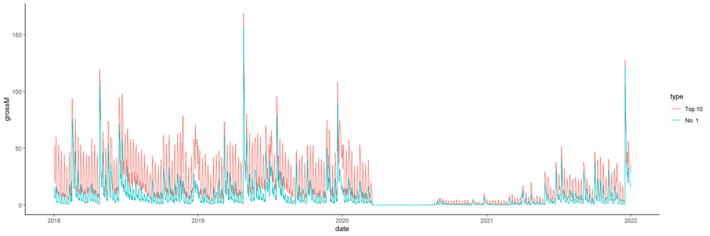

```r
(bom_ln_plot <- bom_plot_data |>
  ggplot() +
  geom_line(aes(x=date, y=grossM, color=type)) +
  theme_classic())
```

### Legend & Lines

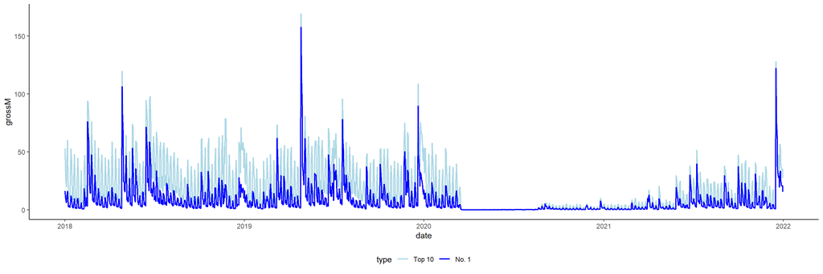

```r
(bom_ln_plot <- bom_plot_data |>
  ggplot() +
  geom_line(aes(x=date, y=grossM, color=type), size=0.75) +
  theme_classic() +
  theme(legend.position="bottom") +
  scale_color_manual(values=c("lightblue","blue")))
```

### X-axis & Labels

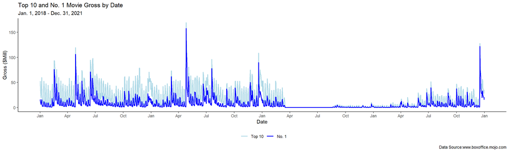

```r
(bom_ln_plot  <- bom_ln_plot +
  scale_x_date(date_breaks = "3 months",         # OG code for date_labels
                 date_labels = "%b") +
  labs(x="Date", y = "Gross ($Mill)", color="",  # modify plot labels
       title="Top 10 and No. 1 Movie Gross by Date",
       subtitle="Jan. 1, 2018 - Dec. 31, 2021",
       caption="Data Source:www.boxoffice.mojo.com"))
```

### Text & Border

- Not required for HW 4

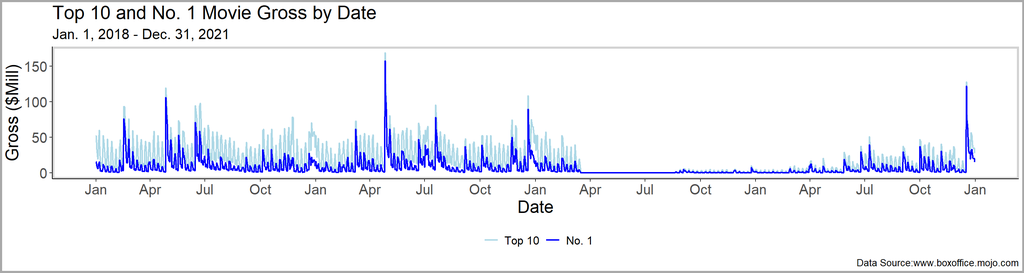

```r
(bom_ln_plot  <- bom_ln_plot +
     theme(plot.title = element_text(size = 20),
        plot.subtitle = element_text(size = 15),
        axis.title = element_text(size=18),
        axis.text = element_text(size=15),
        plot.caption = element_text(size = 10),
        legend.text = element_text(size = 12),
        panel.border = element_rect(colour = "lightgrey", fill=NA, size=2),
        plot.background = element_rect(colour = "darkgrey", fill=NA, size=2)))
```

### Complete Code

- Similar but more complex than complete plot code for HW 4.
- Additional formatting is required for slides
- HW 4 plot code will end with `labs` command.

```r
bom_ln_plot <- bom_plot_data |>
  ggplot() +
  geom_line(aes(x=date, y=grossM, color=type), size=0.75) +
  theme_classic() +
  theme(legend.position="bottom") +                               # position legend at bootom
  scale_color_manual(values=c("lightblue","blue")) +              # modify line colors
  scale_x_date(date_breaks = "3 months",  date_labels = "%b") +   # OG code for date_labels
  labs(x="Date", y = "Gross ($Mill)", color="",                   # modify plot labels
       title="Top 10 and No. 1 Movie Gross by Date",
       subtitle="Jan. 1, 2018 - Dec. 31, 2021",
       caption="Data Source:www.boxoffice.mojo.com") +
  theme(plot.title = element_text(size = 20),                     # text size and borders
        plot.subtitle = element_text(size = 15),
        axis.title = element_text(size=18),
        axis.text = element_text(size=15),
        plot.caption = element_text(size = 10),
        legend.text = element_text(size = 12),
        panel.border = element_rect(colour = "lightgrey", fill=NA, size=2),
        plot.background = element_rect(colour = "darkgrey", fill=NA, size=2))
```

### Final Formatted Line Plot

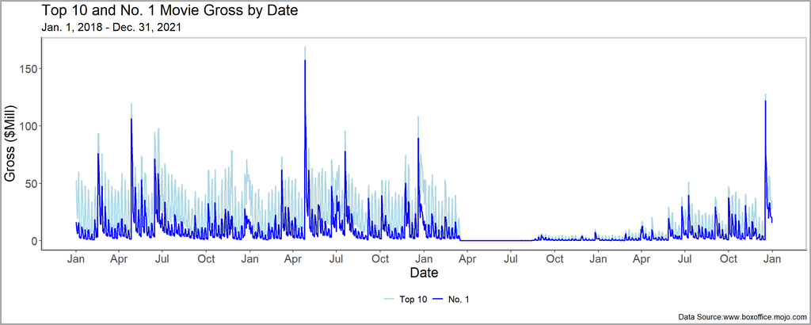

### Bureau of Labor Statistics (BLS) Data

- Bureau of Labor Statistics is an excellent resource for economic data.
- Many (not all) BLS datasets have a similar format.
- In HW 4 you will:
  - Create a function from code use to clean the monthly Unemployment Rate data, `bls_unemp_rate.csv`
  - Use this function to import two related data sets
    - **Export Price Index**
    - **Import Price Index**.
  - Join these two data-sets using a `full_join` and create a `date` variable
  - Modify the the data to create a formatted plot
  - Follow instructions to create a formatted final plot
- Next week: We will adapt this function to examine labor force variables and create an area plot.
- Recall: Before importing ANY data, **ALWAYS** examine the `.csv` file.

### HW 4 - Bureau of Labor Statistics Data

[Bureau of Labor Statistics](https://www.bls.gov/) is a great source for economic data.

In HW 4, we will look at three data sets:

- Unemployment Rate, the percentage of people unemployed (`bls_unemp_rate.csv`)
- Import Price Index (`bls_import_index.csv`)
- Export Price Index (`bls_export_index.csv`)

The Import and Export Price Indices contain data on changes in the prices of nonmilitary goods and services traded between the U.S. and the rest of the world.

- [Documentation on Import and Export Price Indixes](https://www.bls.gov/mxp/)
- [Additional Documention provided by Investopedia](https://www.investopedia.com/terms/i/import-export-prices.asp)
- Before going further, examine these three .csv files to determine number of header rows to skip when cleaning the data

### Introduction to Joins

Earlier today we discussed stacking datasets vertically.

Alternatively, we can join datasets Horizontally if they have matching variables with matching values.

#### **Types of Joins**

- Datasets are joined two at a time, then a third can be joined to first two.
- In BUA 455, we will cover four types of joins (but others exist):
  - `left_join`: include all observations in **FIRST** dataset in join command (dataset on left)
  - `right_join`: include all observations in **SECOND** dataset in join command (dataset on right)
  - `inner_join`: only include observations that are in **BOTH** datasets
  - `full_join`: include all observations that are in **EITHER** dataset
- All joins are useful
- I usually (not always) prefer using `full_join` to help in revealing data errors or discrepancies between multiple datasets.

### Quick note about R colors

- There are [657 Colors in R](https://docs.google.com/spreadsheets/d/1m-UfG96DB4ZAOntVyzcjuYrX564AdLGB2f-MA6rvc2s/edit?usp=sharing)
- We’ll talk more about color options and palettes, but it’s good to know they exist.
- Although we don’t emphasize data visualization theory in this course, you do have to visualize the data in a way that makes it understandable to a client.
- Choosing colors, symbols, size of text, size of lines, etc. wisely is an important part of data management and curation.
- As we transition to discussing the group projects (Next Week), we will start talking more about how to communicate with data effectively.
  - Color choices will be part of that discussion.
- For now, in HW 4 and today’s demo, I manually choose colors so you can see how that works.

### Example of HW 4 Final Plot

**NOTES:**

- Final HW 4 plot should be almost identical to the one below **EXCEPT** for second line of caption.
- Slides version has more formatting. See version in `.html` lecture notes and HW 4 Instructions.

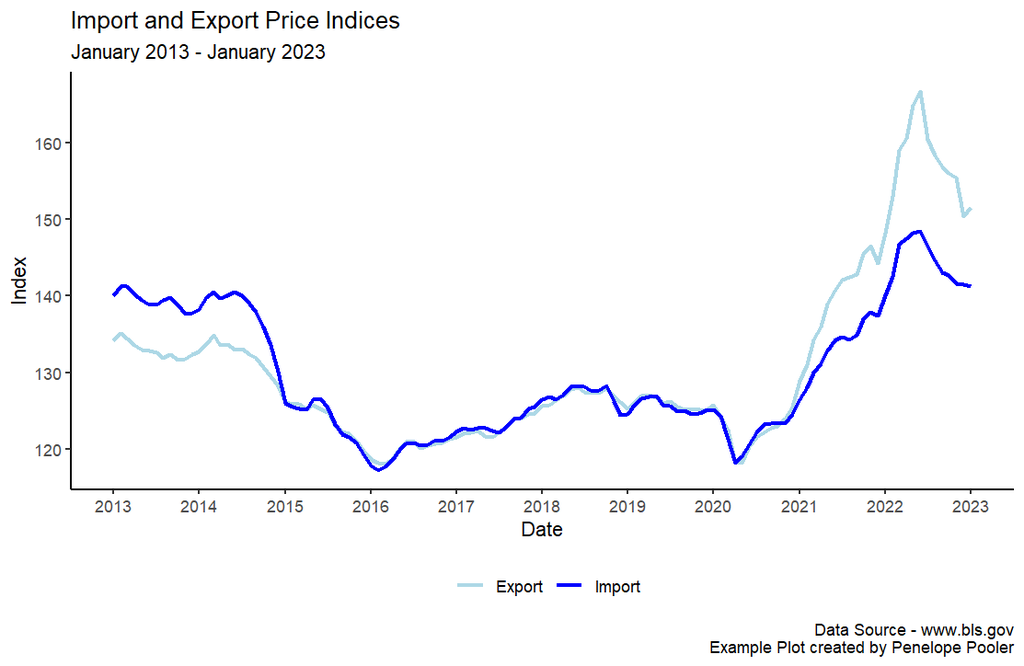

### **Key Points from Week 6**

**Developing Functions:**

- Develop code, convert to a function, test it

** Vertical and Horizontal Data Joins**

- Stack datasets vertically using `bind_rows`
- Join datasets horizontally by matching variables and values (**HW 4:** `full_join`)

**Working with date variables using `lubridate`**

- Command(s) to create date variables
- using `paste` to add year to text

**Next Week**

- More Examples from [BLS](https://www.bls.gov/)
- line and area plots, hcharts and dygraphs
- Converting between data formats
  - `xts` and `tibble`
- Importing stock data from Yahoo Finance to R
- **Introducing the Group Project**

You may submit an ‘Engagement Question’ about each lecture until midnight on the day of the lecture. **A minimum of four submissions are required during the semester.**